# HW 10 Quarto

Author

Justin Pomeranz

# Problems

## Problem 1: preliminaries

# My level 1 header

## My level 2 header

### My level 3 header

## Problem 2: Lists

## My favorite animals

1. Bugs (obviously)
2. Here’s another bug
3. And a third

## Why Use Quarto

- You can make lots of outputs
- You can incorporate code/analysis/results directly in (don’t need to copy/paste plots and stuff every time analysis changes
- Focus on writing, not formatting

## Sub Bulleted list

- Mountain Running
  - Get to see all the sites on a backpacking trip without having to carry so much stuff
  - Makes me feel cool
- Playing the banjo
  - Also makes me feel cool

## Problem 3: Equations

inline: $x \sim Normal(\mu = 0, \sigma = 1)$

Block equations:

$$HA: \mu_{reference} \neq \mu_{treatment}$$

$$s^2 = \frac{\Sigma(y_i - \bar{y})^2}{n-1}$$

## Problem 4: Code Chunks

1. Add a code chunk which loads the tidyverse and reads in the galapago-finches.csv file as an object called `finch` . At the end of the code chunk, display the `finch` object as a tibble

```r
library(tidyverse)
finch <- read.csv(here::here("data/galapago-finches.csv"))
as_tibble(finch)
```

```
# A tibble: 651 × 5
    year  band species blength bdepth
   <int> <int> <chr>     <dbl>  <dbl>
 1  2012 19022 fortis     10      8.5
 2  2012 19028 fortis     12.5    8.9
 3  2012 19032 fortis      9.3    7.5
 4  2012 19041 fortis     10.3    9.6
 5  2012 19044 fortis     11      9.2
 6  2012 19048 fortis     10.1    8.2
 7  2012 19072 fortis      9.6    7.8
 8  2012 19082 fortis     10.9    8.6
 9  2012 19104 fortis     10.3    8.4
10  2012 19114 fortis      9.8    7.7
# ℹ 641 more rows
```

2. Add a code chunk which adds a new column. Name the column `year_factor` and create it by converting the original `year` column into a factor. Make sure to save this calculation as a new object called `finch2` , and display it as a tibble

```r
finch2 <- finch |>
  mutate(year_factor = factor(year))
as_tibble(finch2)
```

```
# A tibble: 651 × 6
    year  band species blength bdepth year_factor
   <int> <int> <chr>     <dbl>  <dbl> <fct>
 1  2012 19022 fortis     10      8.5 2012
 2  2012 19028 fortis     12.5    8.9 2012
 3  2012 19032 fortis      9.3    7.5 2012
 4  2012 19041 fortis     10.3    9.6 2012
 5  2012 19044 fortis     11      9.2 2012
 6  2012 19048 fortis     10.1    8.2 2012
 7  2012 19072 fortis      9.6    7.8 2012
 8  2012 19082 fortis     10.9    8.6 2012
 9  2012 19104 fortis     10.3    8.4 2012
10  2012 19114 fortis      9.8    7.7 2012
# ℹ 641 more rows
```

3. Using `finch2`, make a scatterplot with `bdpeth` on the x-axis and `blength` on the y-axis. Also map the `shape` of the points to change with `year_factor`, and the `color` of the points to change with `species`. Also, add a line of best fit to the plot by using `stat_smooth(method = "lm")`

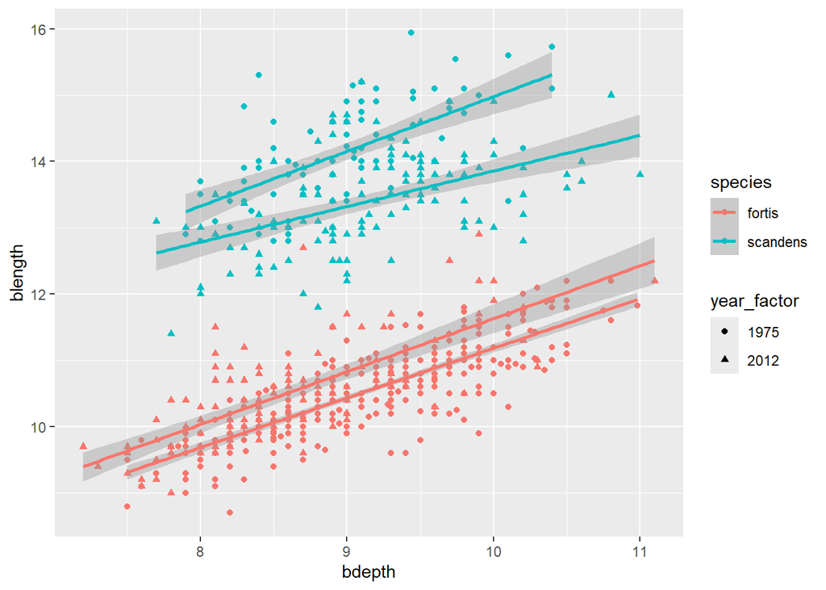

```r
ggplot(finch2,
       aes(x = bdepth,
           y = blength,
           color = species,
           shape = year_factor)) +
  geom_point() +
  stat_smooth(method = "lm")
```

## Problem 5: Miscellany

2. my cmu email address is jpomeranz@colroadomesa.edu
3. Include a line of text which includes at least one
   1. **bold**
   2. *italicized*
   3. subscript H<sub>2</sub>O
   4. superscript M<sup>2</sup>